# Agenda

- Entrance Ticket: [ET_0929](https://bart.instructure.com/courses/2110/quizzes/3203)
  - Review of function translations
- A [new parent-function reference](https://chadworley.github.io/algtwo2026/u02/09_29/parent_functions.pdf)
- [PCW_09_29_graph_parent_translations](https://bart.instructure.com/courses/2110/assignments/28864)
  - Graph 8 shifted parent functions on paper
  - Due today!

# Shifts

- Adding/subtracting in the argument shifts function horizontally. The direction is “backwards”.
- Adding/subtracting outside the function shifts function vertically. The direction is “normal”.
- Examples:
  - If we compare $y=f(x)$ and $y=f(x+2)+3$, the second curve is congruent to the first, but the second curve is shifted 2 units **left** and 3 units **up**.
  - If we compare $y=f(x)$ and $y=f(x-2)+3$, the second curve is congruent to the first, but the second curve is shifted 2 units **right** and 3 units **up**.
  - If we compare $y=f(x)$ and $y=f(x+2)-3$, the second curve is congruent to the first, but the second curve is shifted 2 units **left** and 3 units **down**.
  - If we compare $y=f(x)$ and $y=f(x-2)-3$, the second curve is congruent to the first, but the second curve is shifted 2 units **right** and 3 units **down**.

# Parent functions

- A [pdf of important parent functions](https://chadworley.github.io/algtwo2026/u02/09_29/parent_functions.pdf).

### Absolute-value function

$$y=|x|$$

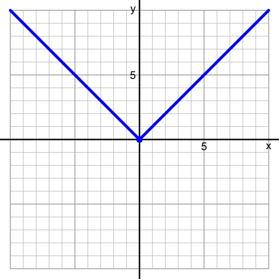

### Reciprocal function

$$y=\frac{1}{x}~~~~\text{or}~~~~y=x^{-1}$$

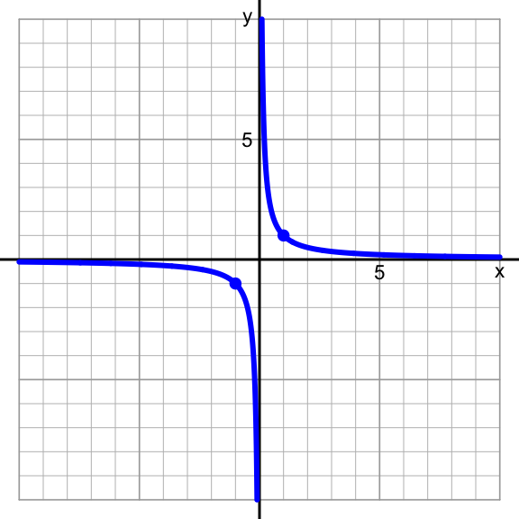

### Squaring function (Quadratic)

$$y=x^2$$

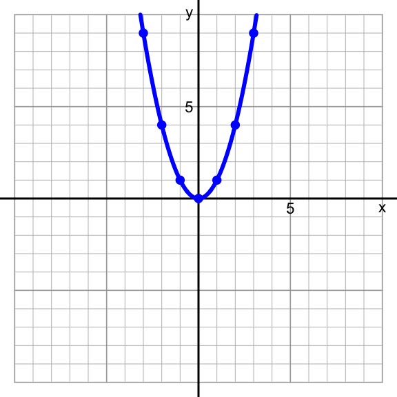

### Square-root function

$$y=\sqrt{x}~~~~\text{or}~~~~y=x^{1/2}$$

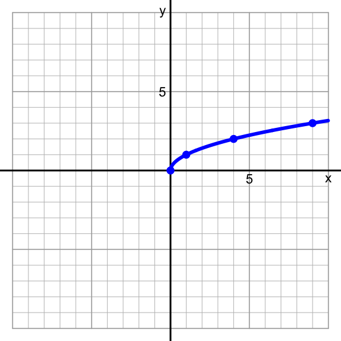

### Cubing function (Cubic)

$$y=x^3$$

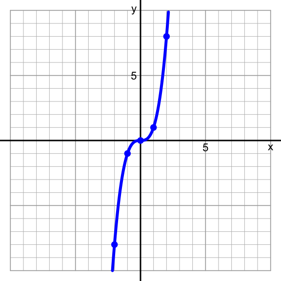

### Cube-root function

$$y=\sqrt[3]{x}~~~~\text{or}~~~~y=x^{1/3}$$

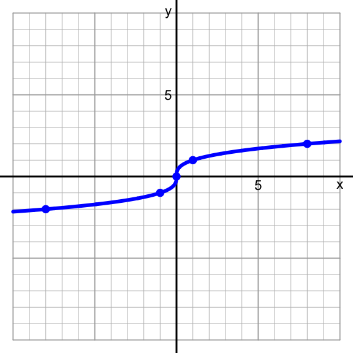

### Exponential (base 2) function

$$y=2^x$$

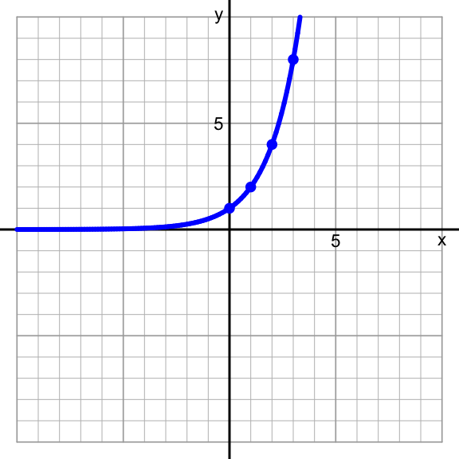

### Logarithmic (base 2) function

$$y=\log_2(x)$$

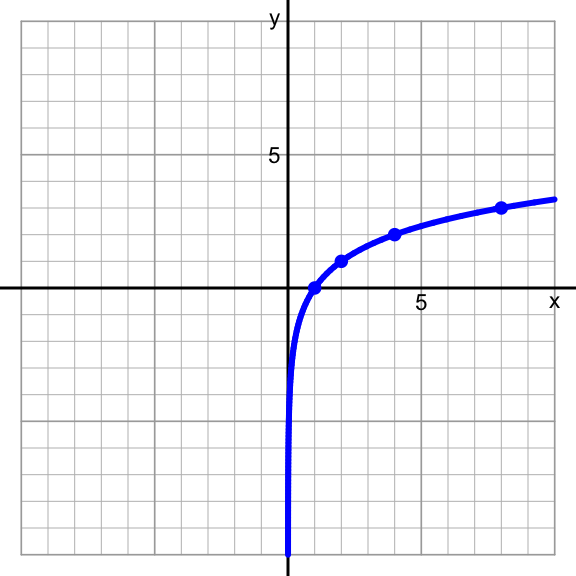